# Advanced data analysis_HW 3

Olga Lavrinenko

2023-11-30

```r
library(foreign)
library(haven)
library(DescTools)
library(gplots)
library(ggplot2)
library(dplyr)
library(tidyverse)
library(naniar)
library(mi)
library(missForest)
library(caret)
library(performance)
library(sjPlot)
library(quantreg)
library(MASS)
```

# Task

This time, we will work with TIMSS data for the 8th grade and predict bullying in American schools. As bullying is not such a frequent thing, it is important to find a fitting method that would target those who do have this experience. For that, we will use quantile regression.

```r
setwd("D:/Data Analytics For Politics And Society/II year_Data Analysis Advanced Level (1-2 modules)/Part II/HT")
data_full <- read.spss("bsgusam7.sav", to.data.frame = TRUE)
```

# 1. Data preporation

Choose the variables: BSBGSB,BSBGSSB, BSBG05A, BSBG05B,BSBG05C, BSBG05D, BSBG05E, BSBG05F, BSBG05G, BSMMAT01, ITSEX, BSBG06A, BSBG06B.

Find what they mean and how they are coded in the Codebook (here: https://timss2019.org/international-database/). NB! Mind the coding!

```r
data_USA <- data_full[, c("BSBGSB", "BSBGSSB", "BSBG05A", "BSBG05B",
                          "BSBG05C", "BSBG05D", "BSBG05E", "BSBG05F", "BSBG05G",
                          "BSBG06A", "BSBG06B", "BSMMAT01", "ITSEX")]
```

[output not shown]

```r
lookup <- c(gender = "ITSEX", bullying = "BSBGSB", belonging = "BSBGSSB",
            computer_tablet = "BSBG05A",  study_desk ="BSBG05B", own_room = "BSBG05C",
            internet = "BSBG05D", own_phone = "BSBG05E", gaming_systems = "BSBG05F", dvd = "BSBG05G",
            math_test = "BSMMAT01", edu_father = "BSBG06A", edu_mother = "BSBG06B")

data_USA <- rename(data_USA, all_of(lookup))
```

# 2. Descriptive analysis

## 2.1 Conduct descriptive analysis. Assign correct variable types.

### 2.1 Gender

This variable is binary, it includes two categories - male and female. The variable contains 5 missing values. The data between categories is distributed evenly: 4344 for female and 4349 for male.

```r
data_USA$gender <- as.factor(data_USA$gender)
class(data_USA$gender)
```

```
## [1] "factor"
```

```r
sum(is.na(data_USA$gender))
```

```
## [1] 5
```

```r
table(data_USA$gender)
```

```
##
## Female   Male
##   4344   4349
```

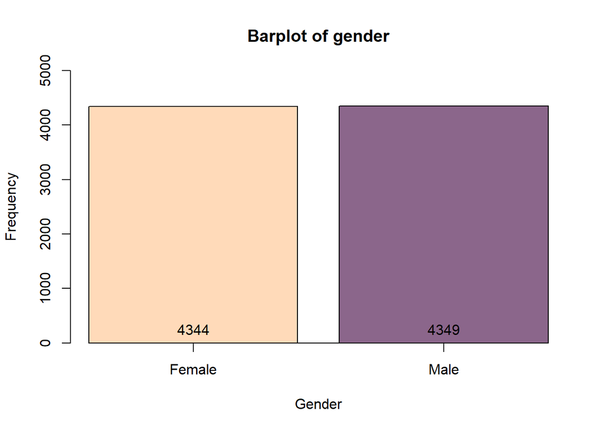

```r
bp_1 <- barplot(table(data_USA$gender),
        beside = T,
        xlab = "Gender",
        ylab = "Frequency",
        ylim = c(0, 5000),
        xaxt = "n",
        main = "Barplot of gender",
        col = c("#FFDAB9", "#8B668B"))

axis(side = 1, at = bp_1[c(1,2)], labels = c("Female", "Male"))

text(bp_1, -1.4, table(data_USA$gender), col = "black", pos = 3)
```

### 2.2 Level of belonging

The type of this variable is numeric, it contains 411 missing values. Data is piled up on the right, so it’s left-skewed data. Minimal value of belonging is 3.92, while maximum is 13.27, and mean is 9.38.

It can be seen that there are several observations where the level of belonging is about 4, these observations are potential outliers. There is also a sufficient frequency of observations indicating a very high level of belonging - about 12-13 (800 - 700 observations each).

```r
class(data_USA$belonging)
```

```
## [1] "factor"
```

```r
data_USA$belonging <- as.numeric(as.character(data_USA$belonging))
summary(data_USA$belonging)
```

```
##    Min. 1st Qu.  Median    Mean 3rd Qu.    Max.    NA's
##   3.924   8.081   9.408   9.376  10.710  13.272     411
```

```r
class(data_USA$belonging)
```

```
## [1] "numeric"
```

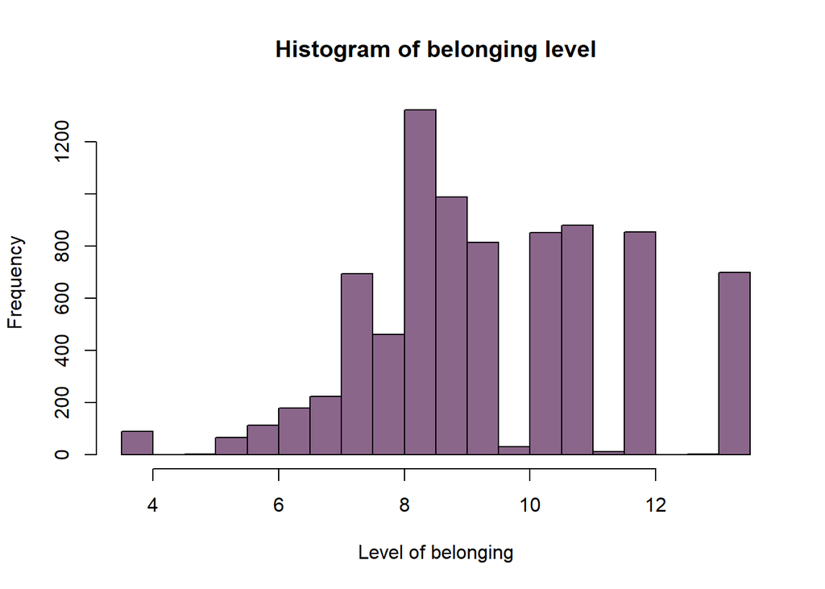

```r
hist(data_USA$belonging,
     main = "Histogram of belonging level",
     xlab = "Level of belonging", col = "#8B668B")
```

### 2.3 Computer tablet

This variable is binary, it includes two categories - “Yes” and “No”. The variable contains 361 missing values. The data between categories is distributed unevenly: 7868 for “Yes” and 469 for “No”.

```r
data_USA$computer_tablet <- as.factor(data_USA$computer_tablet)
class(data_USA$computer_tablet)
```

```
## [1] "factor"
```

```r
sum(is.na(data_USA$computer_tablet))
```

```
## [1] 361
```

```r
table(data_USA$computer_tablet)
```

```
##
##  Yes   No
## 7868  469
```

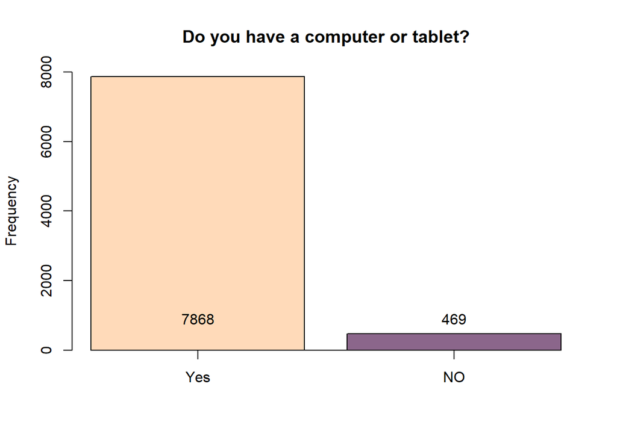

```r
bp_2 <- barplot(table(data_USA$computer_tablet),
        beside = T,
        ylab = "Frequency",
        ylim = c(0, 8000),
        xaxt = "n",
        main = "Do you have a computer or tablet?",
        col = c("#FFDAB9", "#8B668B"))

axis(side = 1, at = bp_2[c(1,2)], labels = c("Yes", "NO"))

text(bp_2, 500, table(data_USA$computer_tablet), col = "black", pos = 3)
```

### 2.4 Study desk

This variable is binary, it includes two categories - “Yes” and “No”. The variable contains 360 missing values. The data between categories is distributed unevenly: 6925 for “Yes” and 1413 for “No”.

```r
data_USA$study_desk <- as.factor(data_USA$study_desk)
class(data_USA$study_desk)
```

```
## [1] "factor"
```

```r
sum(is.na(data_USA$study_desk))
```

```
## [1] 360
```

```r
table(data_USA$study_desk)
```

```
##
##  Yes   No
## 6925 1413
```

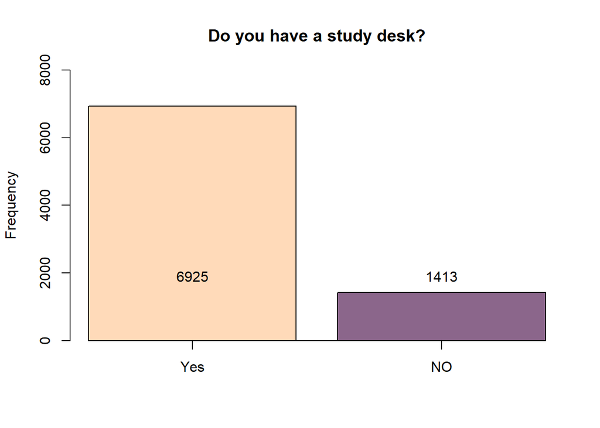

```r
bp_3 <- barplot(table(data_USA$study_desk),
        beside = T,
        ylab = "Frequency",
        ylim = c(0, 8000),
        xaxt = "n",
        main = "Do you have a study desk?",
        col = c("#FFDAB9", "#8B668B"))

axis(side = 1, at = bp_3[c(1,2)], labels = c("Yes", "NO"))

text(bp_3, 1500, table(data_USA$study_desk), col = "black", pos = 3)
```

### 2.5 Own room

This variable is binary, it includes two categories - “Yes” and “No”. The variable contains 355 missing values. The data between categories is distributed unevenly: 6958 for “Yes” and 1385 for “No”.

```r
data_USA$own_room <- as.factor(data_USA$own_room)
class(data_USA$own_room)
```

```
## [1] "factor"
```

```r
sum(is.na(data_USA$own_room))
```

```
## [1] 355
```

```r
table(data_USA$own_room)
```

```
##
##  Yes   No
## 6958 1385
```

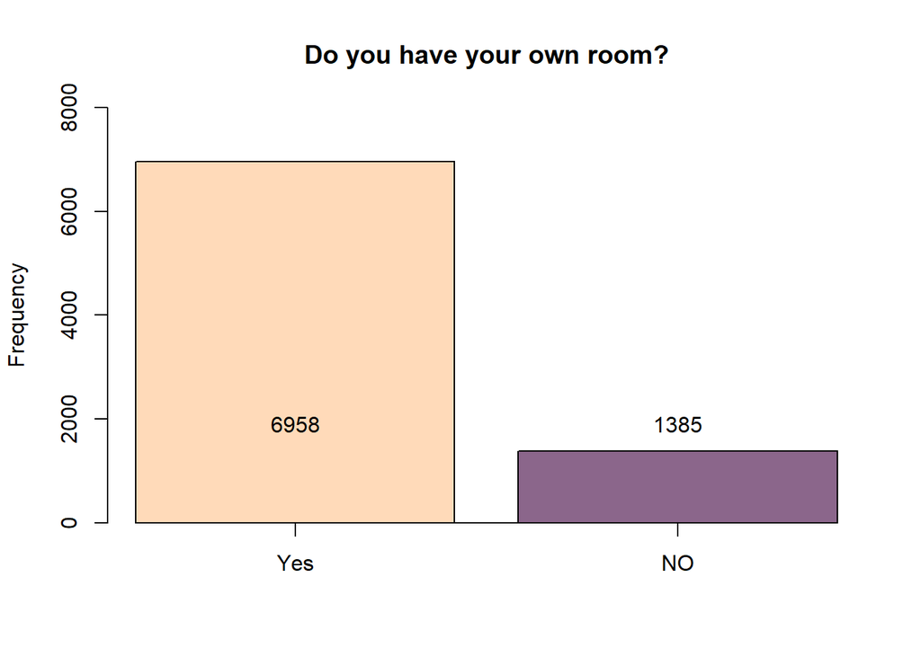

```r
bp_4 <- barplot(table(data_USA$own_room),
        beside = T,
        ylab = "Frequency",
        ylim = c(0, 8000),
        xaxt = "n",
        main = "Do you have your own room?",
        col = c("#FFDAB9", "#8B668B"))

axis(side = 1, at = bp_4[c(1,2)], labels = c("Yes", "NO"))

text(bp_4, 1500, table(data_USA$own_room), col = "black", pos = 3)
```

### 2.6 Internet connection

This variable is binary, it includes two categories - “Yes” and “No”. The variable contains 365 missing values. The data between categories is distributed unevenly: 7984 for “Yes” and 349 for “No”.

```r
data_USA$internet <- as.factor(data_USA$internet)
class(data_USA$internet)
```

```
## [1] "factor"
```

```r
sum(is.na(data_USA$internet))
```

```
## [1] 365
```

```r
table(data_USA$internet)
```

```
##
##  Yes   No
## 7984  349
```

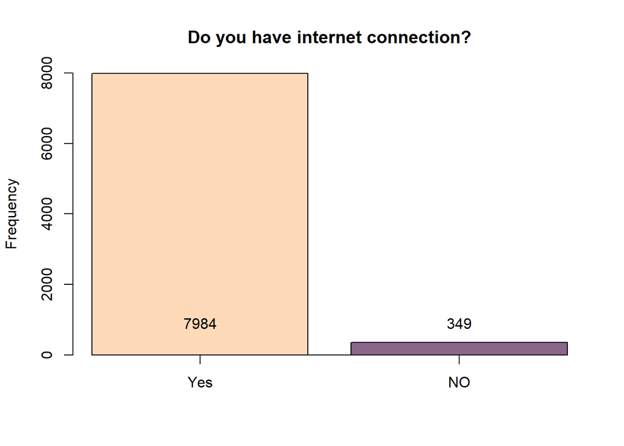

```r
bp_5 <- barplot(table(data_USA$internet),
        beside = T,
        ylab = "Frequency",
        ylim = c(0, 8000),
        xaxt = "n",
        main = "Do you have internet connection?",
        col = c("#FFDAB9", "#8B668B"))

axis(side = 1, at = bp_5[c(1,2)], labels = c("Yes", "NO"))

text(bp_5, 500, table(data_USA$internet), col = "black", pos = 3)
```

### 2.7 Own mobile phone

This variable is binary, it includes two categories - “Yes” and “No”. The variable contains 371 missing values. The data between categories is distributed unevenly: 7804 for “Yes” and 523 for “No”.

```r
data_USA$own_phone <- as.factor(data_USA$own_phone)
class(data_USA$own_phone)
```

```
## [1] "factor"
```

```r
sum(is.na(data_USA$own_phone))
```

```
## [1] 371
```

```r
table(data_USA$own_phone)
```

```
##
##  Yes   No
## 7804  523
```

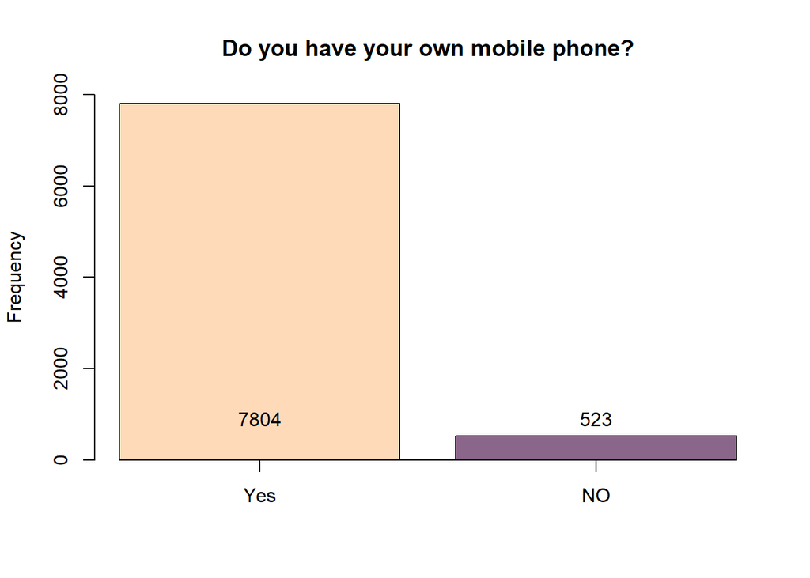

```r
bp_6 <- barplot(table(data_USA$own_phone),
        beside = T,
        ylab = "Frequency",
        ylim = c(0, 8000),
        xaxt = "n",
        main = "Do you have your own mobile phone?",
        col = c("#FFDAB9", "#8B668B"))

axis(side = 1, at = bp_6[c(1,2)], labels = c("Yes", "NO"))

text(bp_6, 500, table(data_USA$own_phone), col = "black", pos = 3)
```

### 2.8 Gaming systems

This variable is binary, it includes two categories - “Yes” and “No”. The variable contains 362 missing values. The data between categories is distributed unevenly: 7234 for “Yes” and 1102 for “No”.

```r
data_USA$gaming_systems <- as.factor(data_USA$gaming_systems)
class(data_USA$gaming_systems)
```

```
## [1] "factor"
```

```r
sum(is.na(data_USA$gaming_systems))
```

```
## [1] 362
```

```r
table(data_USA$gaming_systems)
```

```
##
##  Yes   No
## 7234 1102
```

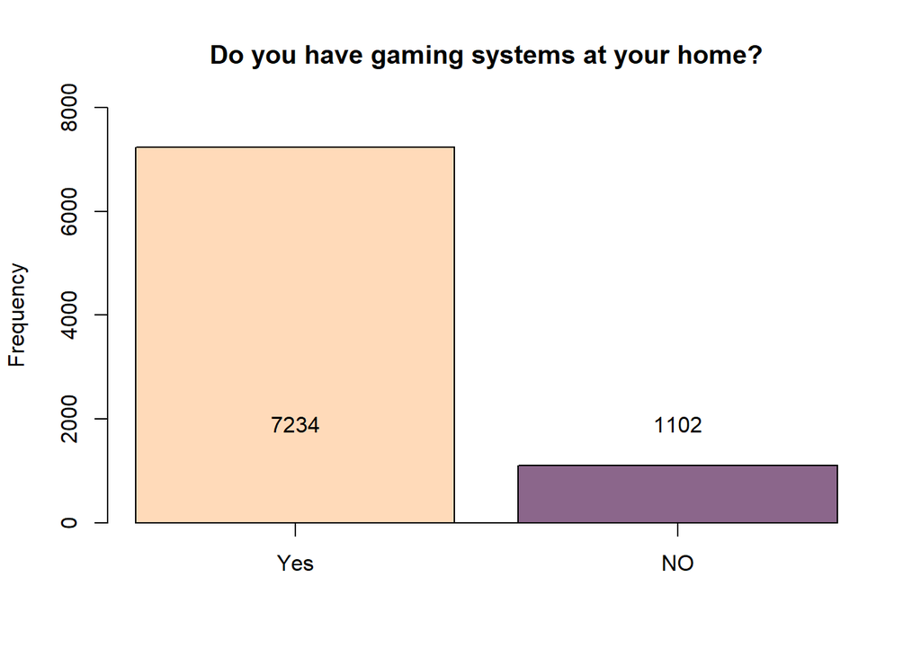

```r
bp_7 <- barplot(table(data_USA$gaming_systems),
        beside = T,
        ylab = "Frequency",
        ylim = c(0, 8000),
        xaxt = "n",
        main = "Do you have gaming systems at your home?",
        col = c("#FFDAB9", "#8B668B"))

axis(side = 1, at = bp_7[c(1,2)], labels = c("Yes", "NO"))

text(bp_7, 1500, table(data_USA$gaming_systems), col = "black", pos = 3)
```

### 2.9 DVDs

This variable is binary, it includes two categories - “Yes” and “No”. The variable contains 368 missing values. The data between categories is distributed unevenly: 6910 for “Yes” and 1420 for “No”.

```r
data_USA$dvd <- as.factor(data_USA$dvd)
class(data_USA$dvd)
```

```
## [1] "factor"
```

```r
sum(is.na(data_USA$dvd))
```

```
## [1] 368
```

```r
table(data_USA$dvd)
```

```
##
##  Yes   No
## 6910 1420
```

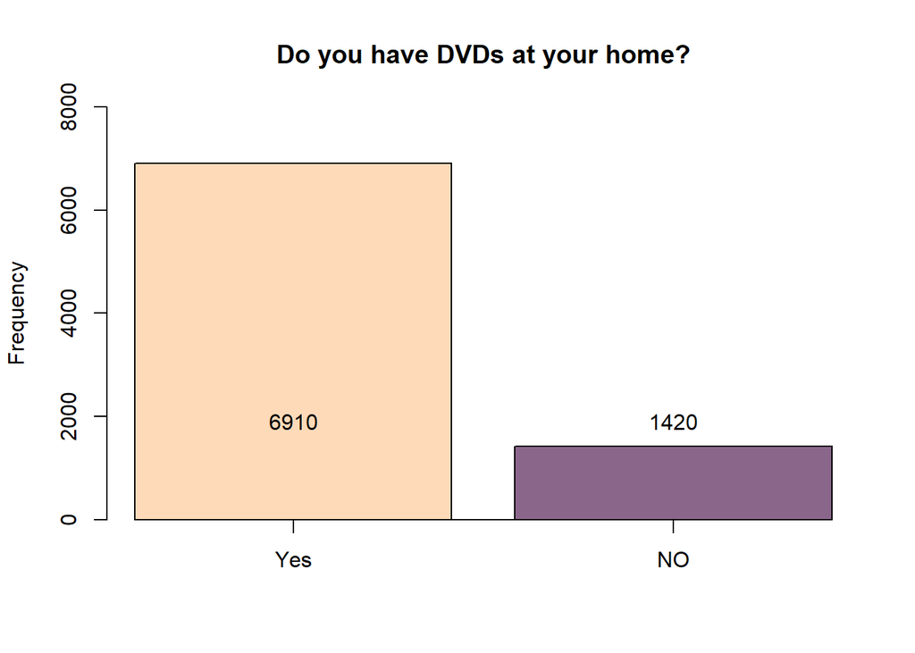

```r
bp_8 <- barplot(table(data_USA$dvd),
        beside = T,
        ylab = "Frequency",
        ylim = c(0, 8000),
        xaxt = "n",
        main = "Do you have DVDs at your home?",
        col = c("#FFDAB9", "#8B668B"))

axis(side = 1, at = bp_8[c(1,2)], labels = c("Yes", "NO"))

text(bp_8, 1500, table(data_USA$dvd), col = "black", pos = 3)
```

### 2.10 Math test

```r
class(data_USA$math_test)
```

```
## [1] "factor"
```

```r
data_USA$math_test <- as.numeric(as.character(data_USA$math_test))
summary(data_USA$math_test)
```

```
##    Min. 1st Qu.  Median    Mean 3rd Qu.    Max.
##   201.1   447.6   518.6   515.7   585.9   824.7
```

```r
class(data_USA$math_test)
```

```
## [1] "numeric"
```

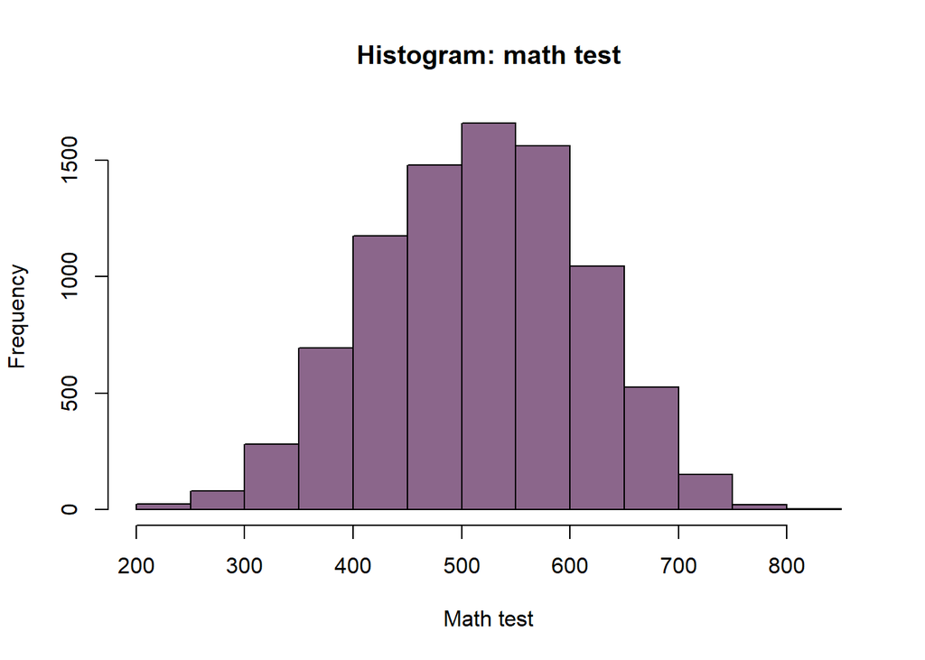

```r
hist(data_USA$math_test,
     main = "Histogram: math test",
     xlab = "Math test", col = "#8B668B")
```

### 2.11 Education level (father)

The variable is categorical and initially it contains 9 categories. But they are distributed completely unevenly, so it was necessary to recode. Finally the variables includes three categories: those whose parent A has higher education (3092), those whose parent A doesn’t (2948), and those who doesn’t know (2187). The last category was quite numerous to be converted into NA, and it wouldn’t be very properly to lose quarter of all observations in the regression.

```r
data_USA$edu_father <- as.factor(data_USA$edu_father)
class(data_USA$edu_father)
```

```
## [1] "factor"
```

```r
sum(is.na(data_USA$edu_father))
```

```
## [1] 471
```

```r
table(data_USA$edu_father)
```

```
##
## Some <Primary education—ISCED Level 1 or Lower secondary education—ISCED Level 2> or did not go to school
##                                                                                                       270
##                                                                 <Lower secondary education—ISCED Level 2>
##                                                                                                       455
##                                                                 <Upper secondary education—ISCED Level 3>
##                                                                                                      1464
##                                                    <Post-secondary, non-tertiary education—ISCED Level 4>
##                                                                                                         0
##                                                            <Short-cycle tertiary education—ISCED Level 5>
##                                                                                                       759
##                                                            <Bachelor’s or equivalent level—ISCED Level 6>
##                                                                                                      1608
##                                    <Postgraduate degree: Master’s—ISCED Level 7 or Doctor —ISCED Level 8>
##                                                                                                      1484
##                                                                                              I don’t know
##                                                                                                      2127
##                                                                                            Not applicable
##                                                                                                        60
```

```r
data_USA$edu_father <- as.numeric(data_USA$edu_father)
data_USA$edu_father <- as.factor(ifelse(data_USA$edu_father < 6, "No higher education",
                            ifelse(data_USA$edu_father >= 8, "I don't know",
                            "Higher education")))
table(data_USA$edu_father)
```

```
##
##    Higher education        I don't know No higher education
##                3092                2187                2948
```

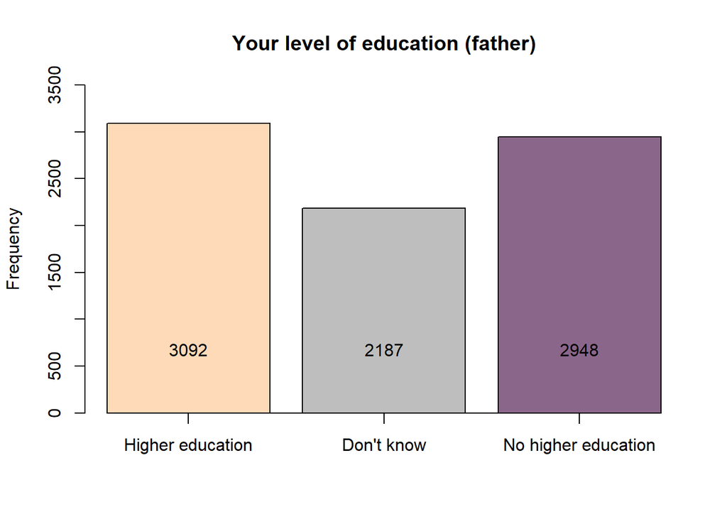

```r
bp_9 <- barplot(table(data_USA$edu_father),
        beside = T,
        ylab = "Frequency",
        ylim = c(0, 3500),
        xaxt = "n",
        main = "Your level of education (father)",
        col = c("#FFDAB9", "grey", "#8B668B"))

axis(side = 1, at = bp_9[c(1,2,3)], labels = c("Higher education", "Don't know", "No higher education"))

text(bp_9, 500, table(data_USA$edu_father), col = "black", pos = 3)
```

### 2.11 Education level (mother)

The variable is categorical and initially it contains 9 categories. But they are distributed completely unevenly, so it was necessary to recode. Finally the variables includes three categories: those whose parent B has higher education (2196), those whose parent B doesn’t (3246), and those who doesn’t know (2583). The last category was quite numerous to be converted into NA, and it wouldn’t be very properly to lose quarter of all observations in the regression.

```r
data_USA$edu_mother <- as.factor(data_USA$edu_mother)
class(data_USA$edu_mother)
```

```
## [1] "factor"
```

```r
sum(is.na(data_USA$edu_mother))
```

```
## [1] 673
```

```r
table(data_USA$edu_mother)
```

```
##
## Some <Primary education—ISCED Level 1 or Lower secondary education—ISCED Level 2> or did not go to school
##                                                                                                       280
##                                                                 <Lower secondary education—ISCED Level 2>
##                                                                                                       505
##                                                                 <Upper secondary education—ISCED Level 3>
##                                                                                                      1724
##                                                    <Post-secondary, non-tertiary education—ISCED Level 4>
##                                                                                                         0
##                                                            <Short-cycle tertiary education—ISCED Level 5>
##                                                                                                       737
##                                                            <Bachelor’s or equivalent level—ISCED Level 6>
##                                                                                                      1338
##                                    <Postgraduate degree: Master’s—ISCED Level 7 or Doctor —ISCED Level 8>
##                                                                                                       858
##                                                                                              I don’t know
##                                                                                                      2455
##                                                                                            Not applicable
##                                                                                                       128
```

```r
data_USA$edu_mother <- as.numeric(data_USA$edu_mother)
data_USA$edu_mother <- as.factor(ifelse(data_USA$edu_mother < 6, "No higher education",
                            ifelse(data_USA$edu_mother >= 8, "I don't know",
                            "Higher education")))
table(data_USA$edu_mother)
```

```
##
##    Higher education        I don't know No higher education
##                2196                2583                3246
```

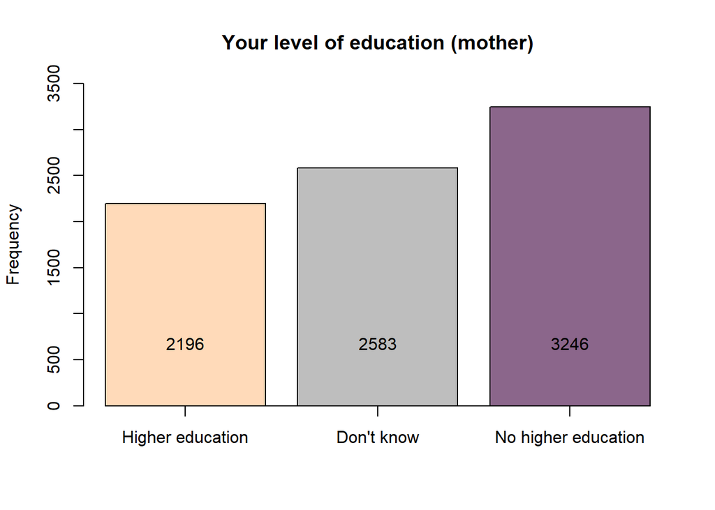

```r
bp_10 <- barplot(table(data_USA$edu_mother),
        beside = T,
        ylab = "Frequency",
        ylim = c(0, 3500),
        xaxt = "n",
        main = "Your level of education (mother)",
        col = c("#FFDAB9", "grey", "#8B668B"))

axis(side = 1, at = bp_10[c(1,2,3)], labels = c("Higher education", "Don't know", "No higher education"))

text(bp_10, 500, table(data_USA$edu_mother), col = "black", pos = 3)
```

## 2.1 Draw the distribution of bullying and describe it.

**Bullying**: The type of this variable is numeric, it contains 422 missing values. Initial data is piled up on the right, so it’s left-skewed data. But the variable is encoded from highest value to lowest value, so it makes sense to flip it for more convenient interpretation.

```r
class(data_USA$bullying)
```

```
## [1] "factor"
```

```r
data_USA$bullying <- as.numeric(as.character(data_USA$bullying))
summary(data_USA$bullying)
```

```
##    Min. 1st Qu.  Median    Mean 3rd Qu.    Max.    NA's
##   1.953   8.505   9.570   9.806  11.188  12.937     422
```

```r
class(data_USA$bullying)
```

```
## [1] "numeric"
```

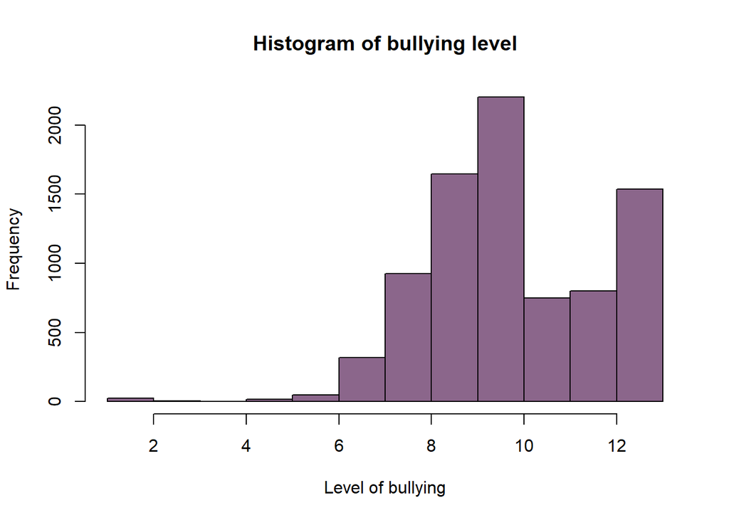

```r
hist(data_USA$bullying,
     main = "Histogram of bullying level",
     xlab = "Level of bullying", col = "#8B668B")
```

Now, after re-cording, it can be seen that there are several observations where the level of bullying is about 12, these observations are potential outliers. There is also a sufficient frequency of observations indicating a very low level of bullying (about 1500 observations).

```r
data_USA$bullying_rev <-
  (max(data_USA$bullying, na.rm = T) - data_USA$bullying) + min(data_USA$bullying, na.rm = T)

summary(data_USA$bullying_rev)
```

```
##    Min. 1st Qu.  Median    Mean 3rd Qu.    Max.    NA's
##   1.953   3.703   5.321   5.085   6.385  12.937     422
```

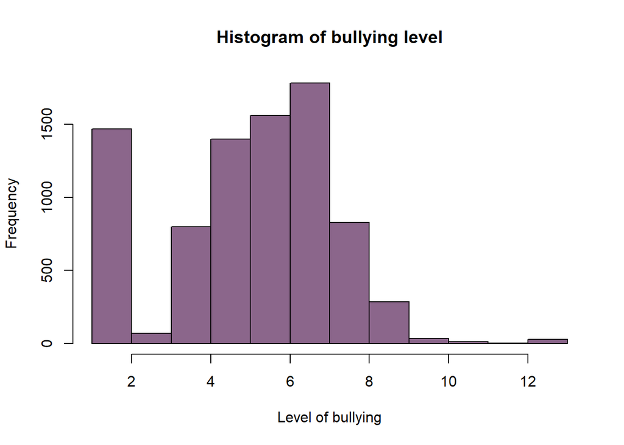

```r
hist(data_USA$bullying_rev,
     main = "Histogram of bullying level",
     xlab = "Level of bullying", col = "#8B668B")
```

## 2.2 Decide whether all the variables can be included in the analysis and explain your choice. Recode some variables if needed (remember that all categories should be saturated with data to achieve a proper result of the analysis)

### 2.2.1 Missings

Firstly, let’s have a look at missings and their proportions. We can see, that the proportion of missing values does not exceed 8%. But we can still carry out imputation. Since we have not only numeric variables, but also categorical (binary) ones, which are the majority, it is better to use random forest method. kNN method requires converting variables into numeric, that is not convenient for the future analysis, and regression imputation is very slow.

```r
as.data.frame(miss_var_summary(data_USA))
```

```
##           variable n_miss   pct_miss
## 1       edu_mother    673 7.73741090
## 2       edu_father    471 5.41503794
## 3         bullying    422 4.85169004
## 4     bullying_rev    422 4.85169004
## 5        belonging    411 4.72522419
## 6        own_phone    371 4.26534836
## 7              dvd    368 4.23085767
## 8         internet    365 4.19636698
## 9   gaming_systems    362 4.16187629
## 10 computer_tablet    361 4.15037940
## 11      study_desk    360 4.13888250
## 12        own_room    355 4.08139802
## 13          gender      5 0.05748448
## 14       math_test      0 0.00000000
```

Let’s carry out imputation based on random forest.

```r
set.seed(123)
imputed_missForest <-  missForest(data_USA, maxiter = 3, verbose = TRUE)
```

```
##   missForest iteration 1 in progress...done!
##     estimated error(s): 0.004185405 0.2146214
##     difference(s): 2.115127e-07 0.008645666
##     time: 74.89 seconds
##
##   missForest iteration 2 in progress...done!
##     estimated error(s): 0.004154866 0.2130563
##     difference(s): 5.466234e-08 0.003897448
##     time: 67.88 seconds
##
##   missForest iteration 3 in progress...done!
##     estimated error(s): 0.004184937 0.2135692
##     difference(s): 4.235317e-08 0.002552311
##     time: 70.76 seconds
```

```r
data_USA <- as.data.frame(imputed_missForest$ximp)
```

If we compare imputed and original variable “belonging” (numeric) and “owning a phone” (binary), we may notice that the distribution of values is very similar in imputed and original dataset. For belonging mean and median values are pretty close to each other, while the 1st and the 3rd quartile are absolutely the same. It means, that imputation didn’t change our data dramatically.

```r
summary(as.numeric(as.character(data_full$BSBGSSB)))
```

```
##    Min. 1st Qu.  Median    Mean 3rd Qu.    Max.    NA's
##   3.924   8.081   9.408   9.376  10.710  13.272     411
```

```r
summary(data_USA$belonging)
```

```
##    Min. 1st Qu.  Median    Mean 3rd Qu.    Max.
##   3.924   8.081   9.024   9.358  10.710  13.272
```

```r
summary(data_full$BSBG05E)
```

```
##  Yes   No NA's
## 7804  523  371
```

```r
summary(data_USA$own_phone)
```

```
##  Yes   No
## 8169  529
```

### 2.2.2 Variables selection for the analysis

Following variables can be included in the analysis because all categories are more or less saturated - at least 1000 observations per category:

```
- Gender
- Level of belonging
- Owning study desk
- Owning room
- Owning gaming systems
- Owning DVDs
- Math test
- Educational level of parent A
- Educational level of parent B
```

In other factor variables, in particular in binary ones, the category “NO” is not saturated - about 400-500 observations. So we can’t use these variables for the analysis.

# 3. Draw bivariate plots for bullying and predictors. Describe them. Analyze for potential heteroscedasticity and outliers; for nonlinearity if predictor is numeric.

## 3.1 Bullying and belonging

Correlation: p-value is significant (p-value < 0.05), so we can speak about the correlation between these variables. Correlation is small (- 0.29) and negative: the higher belonging to school, the lower level of bullying. The relation is not linear: from 4th to 6th level of belonging level of bullying almost doesn’t change, and than it starts decreasing.

Also, observations are distributed unevenly relative to Y axis. There are observations with very low values of bullying, and with very high values of bullying. This situation may cause heteroscedasticity in the regression. In this case, the bulk of observations are concentrated in the middle of DV scale.

```r
cor.test(data_USA$bullying_rev, data_USA$belonging)
```

```
##
##  Pearson's product-moment correlation
##
## data:  data_USA$bullying_rev and data_USA$belonging
## t = -28.549, df = 8696, p-value < 2.2e-16
## alternative hypothesis: true correlation is not equal to 0
## 95 percent confidence interval:
##  -0.3118379 -0.2734066
## sample estimates:
##        cor
## -0.2927405
```

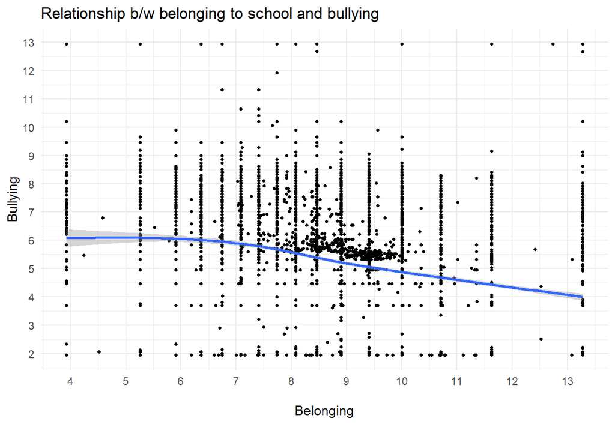

```r
ggplot(data = data_USA,
       mapping = aes(x = belonging, y = bullying_rev)) +
  geom_point(size = 0.9) +
  geom_smooth()+
   ggtitle("Relationship b/w belonging to school and bullying")+
  labs(x = "\nBelonging\n",
       y = "Bullying")+
  scale_x_continuous(breaks = seq(0, 13, 1))+
  scale_y_continuous(breaks = seq(0, 13, 1))+
  theme_minimal()
```

## 3.2 Bullying and gender

T-test: p-value is significant (p-value < 0.05), so we can speak about the association between these variables. Male respondents are likely to have lower level of bullying (~ 5.0) than female respondents (~ 5.2).

```r
t.test(data_USA$bullying_rev ~ data_USA$gender)
```

```
##
##  Welch Two Sample t-test
##
## data:  data_USA$bullying_rev by data_USA$gender
## t = 6.3649, df = 8669.8, p-value = 2.053e-10
## alternative hypothesis: true difference in means between group Female and group Male is not equal to 0
## 95 percent confidence interval:
##  0.1786848 0.3377266
## sample estimates:
## mean in group Female   mean in group Male
##             5.243658             4.985452
```

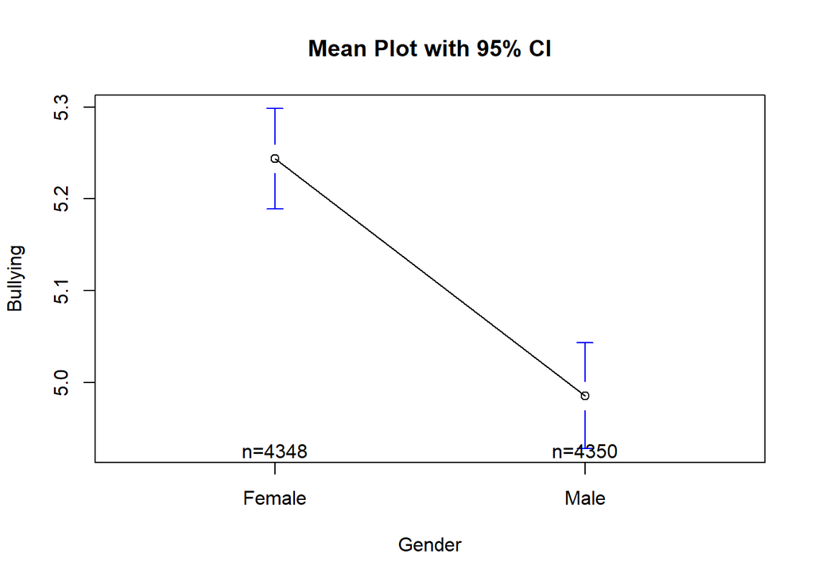

```r
plotmeans(bullying_rev ~ gender, data = data_USA,
          xlab = "Gender", ylab = "Bullying",
          main="Mean Plot with 95% CI")
```

## 3.3 Bullying and owning study desk

T-test: p-value is significant (< 0.05), so we can speak about the association between these variables. Respondents who have their own study desk are likely to have lower level of bullying (~ 5.1) than respondents who don’t have their own study desk (~ 5.3).

```r
t.test(data_USA$bullying_rev ~ data_USA$study_desk)
```

```
##
##  Welch Two Sample t-test
##
## data:  data_USA$bullying_rev by data_USA$study_desk
## t = -3.5518, df = 2217.6, p-value = 0.0003905
## alternative hypothesis: true difference in means between group Yes and group No is not equal to 0
## 95 percent confidence interval:
##  -0.29781193 -0.08593664
## sample estimates:
## mean in group Yes  mean in group No
##          5.080531          5.272405
```

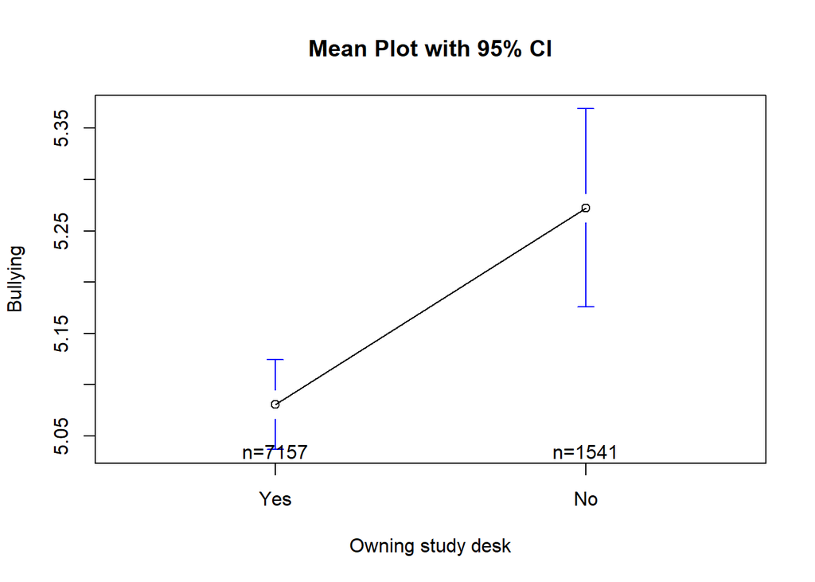

```r
plotmeans(bullying_rev ~ study_desk, data = data_USA,
          xlab = "Owning study desk", ylab = "Bullying",
          main="Mean Plot with 95% CI")
```

## 3.4 Bullying and owning room

T-test: p-value is not significant (> 0.05), so we can’t speak about the association between these variables.

```r
t.test(data_USA$bullying_rev ~ data_USA$own_room)
```

```
##
##  Welch Two Sample t-test
##
## data:  data_USA$bullying_rev by data_USA$own_room
## t = -1.3546, df = 2249.5, p-value = 0.1757
## alternative hypothesis: true difference in means between group Yes and group No is not equal to 0
## 95 percent confidence interval:
##  -0.17433267  0.03188629
## sample estimates:
## mean in group Yes  mean in group No
##          5.102087          5.173310
```

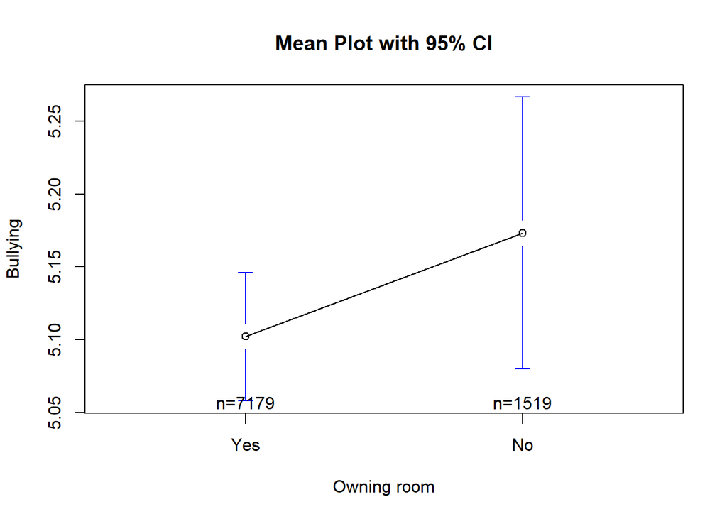

```r
plotmeans(bullying_rev ~ own_room, data = data_USA,
          xlab = "Owning room", ylab = "Bullying",
          main="Mean Plot with 95% CI")
```

## 3.5 Bullying and owning gaming system

T-test: p-value is significant (< 0.05), so we can speak about the association between these variables. Respondents who have their own gaming systems are likely to have lower level of bullying (~ 5.1) than respondents who don’t have their own gaming systems (~ 5.3).

```r
t.test(data_USA$bullying_rev ~ data_USA$gaming_systems)
```

```
##
##  Welch Two Sample t-test
##
## data:  data_USA$bullying_rev by data_USA$gaming_systems
## t = -3.7385, df = 1738.7, p-value = 0.0001911
## alternative hypothesis: true difference in means between group Yes and group No is not equal to 0
## 95 percent confidence interval:
##  -0.31335682 -0.09770372
## sample estimates:
## mean in group Yes  mean in group No
##          5.085508          5.291038
```

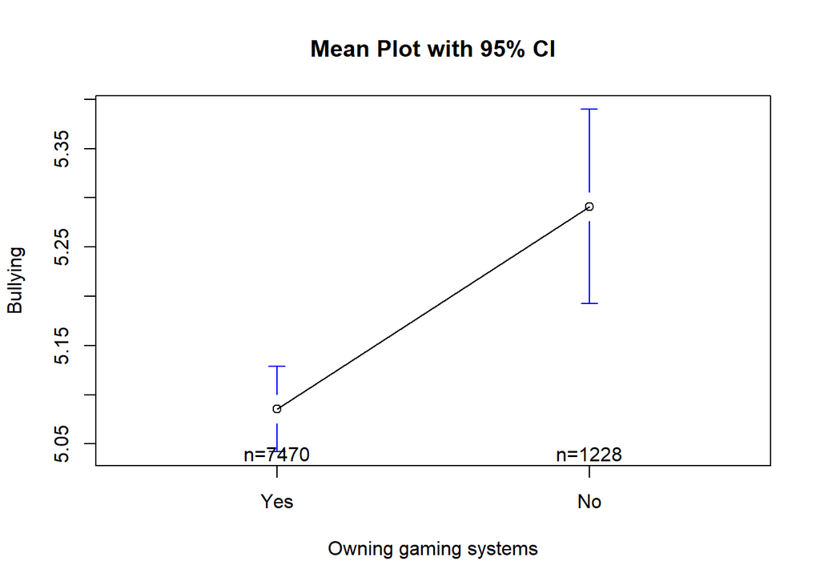

```r
plotmeans(bullying_rev ~ gaming_systems, data = data_USA,
          xlab = "Owning gaming systems", ylab = "Bullying",
          main="Mean Plot with 95% CI")
```

## 3.6 Bullying and Owning DVDs

T-test: p-value is not significant (> 0.05), so we can’t speak about the association between these variables.

```r
t.test(data_USA$bullying_rev ~ data_USA$dvd)
```

```
##
##  Welch Two Sample t-test
##
## data:  data_USA$bullying_rev by data_USA$dvd
## t = 0.032723, df = 2097.3, p-value = 0.9739
## alternative hypothesis: true difference in means between group Yes and group No is not equal to 0
## 95 percent confidence interval:
##  -0.1074967  0.1111449
## sample estimates:
## mean in group Yes  mean in group No
##          5.114840          5.113015
```

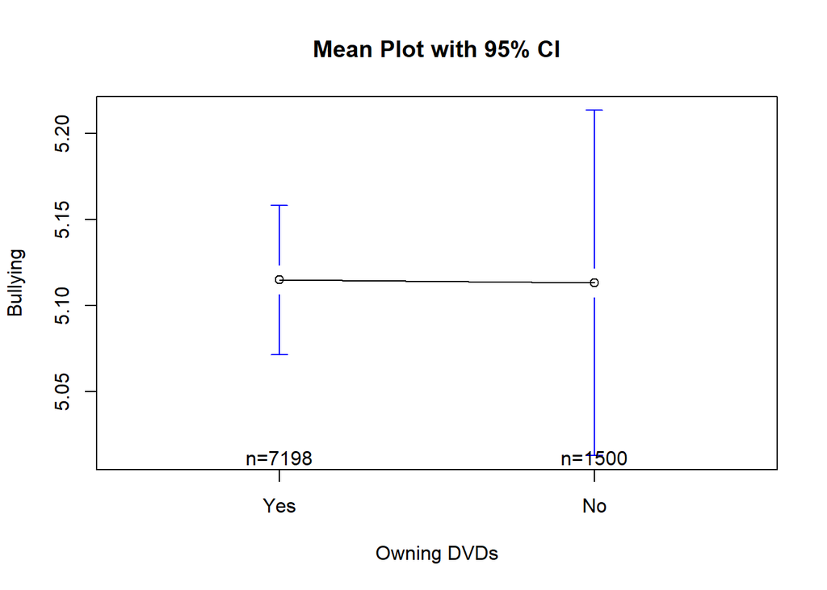

```r
plotmeans(bullying_rev ~ dvd, data = data_USA,
          xlab = "Owning DVDs", ylab = "Bullying",
          main="Mean Plot with 95% CI")
```

## 3.7 Bullying and math_test

Correlation: p-value is significant (p-value < 2.2e-16), so we can speak about the correlation between these variables. Correlation is small (-0.13) and negative: the higher results of math test, the lower level of bullying. And relation is almost linear. Also, observations are distributed unevenly relative to Y axis. There are observations with very low values of bullying, and with very high values of bullying. This situation may cause heteroscedasticity in the regression. In this case, the bulk of observations are concentrated in the middle of DV scale.

```r
cor.test(data_USA$bullying_rev, data_USA$math_test)
```

```
##
##  Pearson's product-moment correlation
##
## data:  data_USA$bullying_rev and data_USA$math_test
## t = -12.011, df = 8696, p-value < 2.2e-16
## alternative hypothesis: true correlation is not equal to 0
## 95 percent confidence interval:
##  -0.1483672 -0.1070209
## sample estimates:
##        cor
## -0.1277495
```

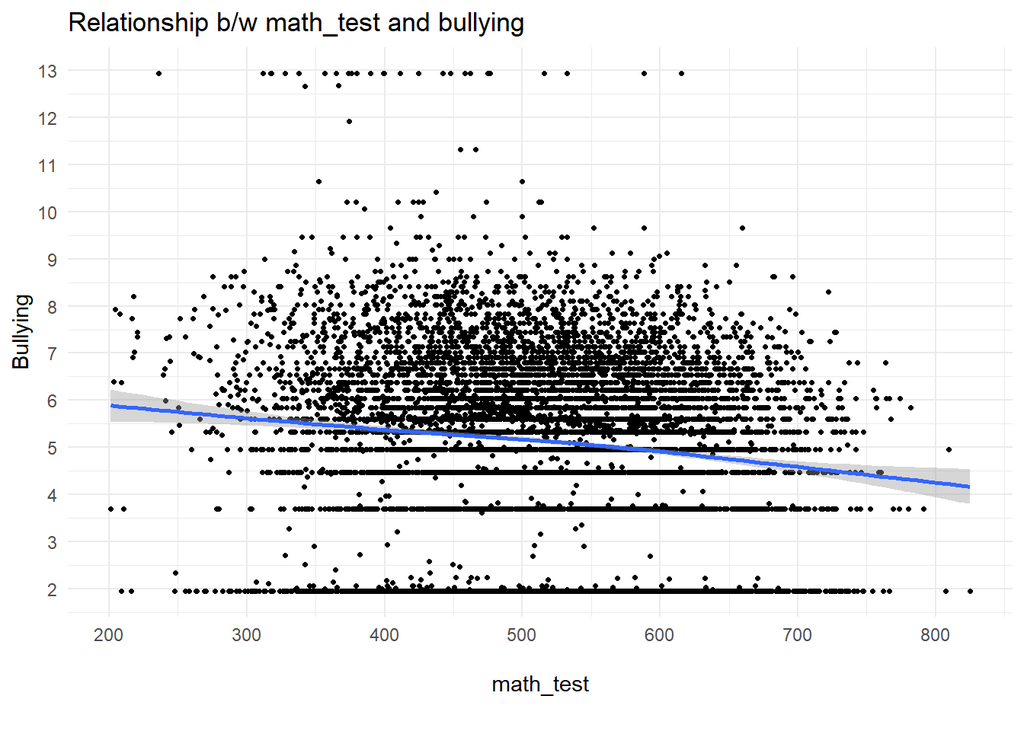

```r
ggplot(data = data_USA,
       mapping = aes(x = math_test, y = bullying_rev)) +
  geom_point(size = 0.9) +
  geom_smooth()+
   ggtitle("Relationship b/w math_test and bullying")+
  labs(x = "\nmath_test\n",
       y = "Bullying")+
  scale_x_continuous(breaks = seq(200, 800, 100))+
  scale_y_continuous(breaks = seq(1, 13, 1))+
  theme_minimal()
```

## 3.8 Bullying and level of parental education (father)

Anova: p-value is significant (p-value < 0.05), so we can speak about the association between these variables. Respondents whose father has higher education show lower level of bullying (5.1) than those whose father doesn’t have higher education (5.3). Respondents who don’t know about father’s education shows lower level of bullying (5.0) than those whose father doesn’t have higher education (5.3).

```r
summary(aov(data_USA$bullying_rev ~ data_USA$edu_father))
```

```
##                       Df Sum Sq Mean Sq F value Pr(>F)
## data_USA$edu_father    2    160   80.10   22.39  2e-10 ***
## Residuals           8695  31104    3.58
## ---
## Signif. codes:  0 '***' 0.001 '**' 0.01 '*' 0.05 '.' 0.1 ' ' 1
```

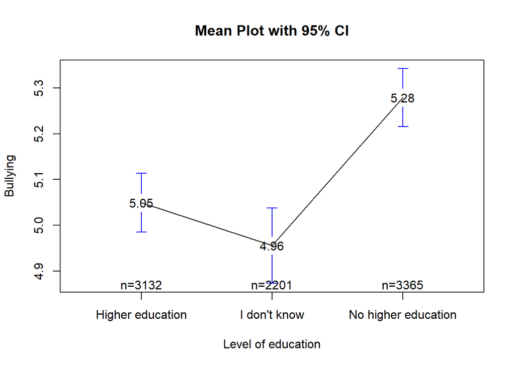

```r
plotmeans(bullying_rev ~ edu_father, data = data_USA,
          xlab = "Level of education", ylab = "Bullying",
          main ="Mean Plot with 95% CI", mean.labels = T, digits = 2, pch=".")
```

## 3.9 Bullying and level of parental education (mother)

Anova: p-value is significant (p-value < 0.05), so we can speak about the association between these variables. Respondents whose mother has higher education show lower level of bullying (5.1) than those whose mother doesn’t have higher education (5.3). Respondents who don’t know about mother’s education shows lower level of bullying (4.9) than those whose mother doesn’t have higher education (5.3).

```r
summary(aov(data_USA$bullying_rev ~ data_USA$edu_mother))
```

```
##                       Df Sum Sq Mean Sq F value  Pr(>F)
## data_USA$edu_mother    2    188   94.18   26.35 3.9e-12 ***
## Residuals           8695  31076    3.57
## ---
## Signif. codes:  0 '***' 0.001 '**' 0.01 '*' 0.05 '.' 0.1 ' ' 1
```

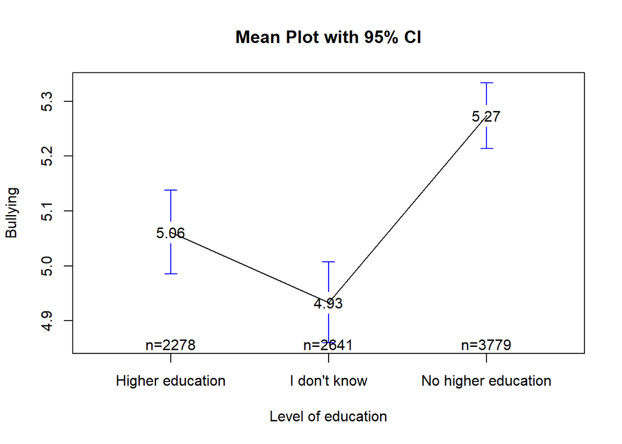

```r
plotmeans(bullying_rev ~ edu_mother, data = data_USA,
          xlab = "Level of education", ylab = "Bullying",
          main ="Mean Plot with 95% CI", mean.labels = T, digits = 2, pch=".")
```

# 4. Run an OLS regression predicting bullying. Build it via forward selection. Give technical interpretation of the final model.

## 4.1 + Gender

```r
model_1 <- lm(bullying_rev ~ gender, data = data_USA)
summary(model_1)
```

```
##
## Call:
## lm(formula = bullying_rev ~ gender, data = data_USA)
##
## Residuals:
##     Min      1Q  Median      3Q     Max
## -3.2902 -1.2825  0.3356  1.2381  7.9519
##
## Coefficients:
##             Estimate Std. Error t value Pr(>|t|)
## (Intercept)  5.24366    0.02869 182.777  < 2e-16 ***
## genderMale  -0.25821    0.04057  -6.365 2.05e-10 ***
## ---
## Signif. codes:  0 '***' 0.001 '**' 0.01 '*' 0.05 '.' 0.1 ' ' 1
##
## Residual standard error: 1.892 on 8696 degrees of freedom
## Multiple R-squared:  0.004637,   Adjusted R-squared:  0.004523
## F-statistic: 40.51 on 1 and 8696 DF,  p-value: 2.054e-10
```

## 4.2 + Belonging

```r
model_2 <- lm(bullying_rev ~ gender + belonging, data = data_USA)
summary(model_2)
```

```
##
## Call:
## lm(formula = bullying_rev ~ gender + belonging, data = data_USA)
##
## Residuals:
##    Min     1Q Median     3Q    Max
## -4.847 -1.017  0.279  1.202  9.069
##
## Coefficients:
##             Estimate Std. Error t value Pr(>|t|)
## (Intercept)  7.93388    0.09843  80.606  < 2e-16 ***
## genderMale  -0.23263    0.03881  -5.994 2.13e-09 ***
## belonging   -0.28883    0.01015 -28.460  < 2e-16 ***
## ---
## Signif. codes:  0 '***' 0.001 '**' 0.01 '*' 0.05 '.' 0.1 ' ' 1
##
## Residual standard error: 1.809 on 8695 degrees of freedom
## Multiple R-squared:  0.08946,    Adjusted R-squared:  0.08925
## F-statistic: 427.1 on 2 and 8695 DF,  p-value: < 2.2e-16
```

## 4.3 + Owning study desk

```r
model_3 <- lm(bullying_rev ~ gender + belonging + study_desk, data = data_USA)
summary(model_3)
```

```
##
## Call:
## lm(formula = bullying_rev ~ gender + belonging + study_desk,
##     data = data_USA)
##
## Residuals:
##     Min      1Q  Median      3Q     Max
## -4.8751 -1.0160  0.2823  1.2045  9.0737
##
## Coefficients:
##              Estimate Std. Error t value Pr(>|t|)
## (Intercept)   7.91905    0.10031  78.942  < 2e-16 ***
## genderMale   -0.23445    0.03889  -6.029 1.72e-09 ***
## belonging    -0.28789    0.01022 -28.163  < 2e-16 ***
## study_deskNo  0.03929    0.05127   0.766    0.443
## ---
## Signif. codes:  0 '***' 0.001 '**' 0.01 '*' 0.05 '.' 0.1 ' ' 1
##
## Residual standard error: 1.809 on 8694 degrees of freedom
## Multiple R-squared:  0.08952,    Adjusted R-squared:  0.08921
## F-statistic: 284.9 on 3 and 8694 DF,  p-value: < 2.2e-16
```

## 4.4 + Owning room

```r
model_4 <- lm(bullying_rev ~ gender + belonging + study_desk + own_room, data = data_USA)
summary(model_4)
```

```
##
## Call:
## lm(formula = bullying_rev ~ gender + belonging + study_desk +
##     own_room, data = data_USA)
##
## Residuals:
##     Min      1Q  Median      3Q     Max
## -4.8991 -1.0104  0.2883  1.1975  9.0784
##
## Coefficients:
##              Estimate Std. Error t value Pr(>|t|)
## (Intercept)   7.91426    0.10055  78.711  < 2e-16 ***
## genderMale   -0.23280    0.03896  -5.975 2.39e-09 ***
## belonging    -0.28801    0.01022 -28.170  < 2e-16 ***
## study_deskNo  0.03173    0.05239   0.606    0.545
## own_roomNo    0.03678    0.05228   0.704    0.482
## ---
## Signif. codes:  0 '***' 0.001 '**' 0.01 '*' 0.05 '.' 0.1 ' ' 1
##
## Residual standard error: 1.81 on 8693 degrees of freedom
## Multiple R-squared:  0.08957,    Adjusted R-squared:  0.08915
## F-statistic: 213.8 on 4 and 8693 DF,  p-value: < 2.2e-16
```

## 4.5 + Owning gaming system

```r
model_5 <- lm(bullying_rev ~ gender + belonging + study_desk + own_room +
                gaming_systems, data = data_USA)
summary(model_5)
```

```
##
## Call:
## lm(formula = bullying_rev ~ gender + belonging + study_desk +
##     own_room + gaming_systems, data = data_USA)
##
## Residuals:
##     Min      1Q  Median      3Q     Max
## -4.9572 -1.0093  0.2752  1.2089  9.0808
##
## Coefficients:
##                  Estimate Std. Error t value Pr(>|t|)
## (Intercept)       7.89582    0.10123  77.998  < 2e-16 ***
## genderMale       -0.21730    0.04020  -5.405 6.65e-08 ***
## belonging        -0.28797    0.01022 -28.168  < 2e-16 ***
## study_deskNo      0.02324    0.05266   0.441    0.659
## own_roomNo        0.03119    0.05239   0.595    0.552
## gaming_systemsNo  0.09053    0.05800   1.561    0.119
## ---
## Signif. codes:  0 '***' 0.001 '**' 0.01 '*' 0.05 '.' 0.1 ' ' 1
##
## Residual standard error: 1.809 on 8692 degrees of freedom
## Multiple R-squared:  0.08983,    Adjusted R-squared:  0.0893
## F-statistic: 171.6 on 5 and 8692 DF,  p-value: < 2.2e-16
```

## 4.6 + Owning DVDs

```r
model_6 <- lm(bullying_rev ~ gender + belonging + study_desk + own_room +
                gaming_systems + dvd, data = data_USA)
summary(model_6)
```

```
##
## Call:
## lm(formula = bullying_rev ~ gender + belonging + study_desk +
##     own_room + gaming_systems + dvd, data = data_USA)
##
## Residuals:
##     Min      1Q  Median      3Q     Max
## -5.0150 -0.9998  0.2809  1.1989  9.0676
##
## Coefficients:
##                  Estimate Std. Error t value Pr(>|t|)
## (Intercept)       7.92120    0.10178  77.825  < 2e-16 ***
## genderMale       -0.20919    0.04034  -5.186  2.2e-07 ***
## belonging        -0.28951    0.01024 -28.268  < 2e-16 ***
## study_deskNo      0.04031    0.05315   0.758   0.4483
## own_roomNo        0.03667    0.05243   0.699   0.4843
## gaming_systemsNo  0.10639    0.05837   1.823   0.0684 .
## dvdNo            -0.12354    0.05274  -2.343   0.0192 *
## ---
## Signif. codes:  0 '***' 0.001 '**' 0.01 '*' 0.05 '.' 0.1 ' ' 1
##
## Residual standard error: 1.809 on 8691 degrees of freedom
## Multiple R-squared:  0.0904, Adjusted R-squared:  0.08977
## F-statistic:   144 on 6 and 8691 DF,  p-value: < 2.2e-16
```

## 4.7 + Math test

```r
model_7 <- lm(bullying_rev ~ gender + belonging + study_desk + own_room +
                gaming_systems + dvd + math_test, data = data_USA)
summary(model_7)
```

```
##
## Call:
## lm(formula = bullying_rev ~ gender + belonging + study_desk +
##     own_room + gaming_systems + dvd + math_test, data = data_USA)
##
## Residuals:
##     Min      1Q  Median      3Q     Max
## -5.0876 -1.0273  0.2788  1.1944  8.9139
##
## Coefficients:
##                    Estimate Std. Error t value Pr(>|t|)
## (Intercept)       8.3921482  0.1350130  62.158  < 2e-16 ***
## genderMale       -0.2074177  0.0402786  -5.150 2.67e-07 ***
## belonging        -0.2757053  0.0105522 -26.128  < 2e-16 ***
## study_deskNo     -0.0028402  0.0536895  -0.053  0.95781
## own_roomNo        0.0190425  0.0524563   0.363  0.71660
## gaming_systemsNo  0.1130678  0.0582971   1.940  0.05247 .
## dvdNo            -0.1569214  0.0530292  -2.959  0.00309 **
## math_test        -0.0011353  0.0002143  -5.298 1.20e-07 ***
## ---
## Signif. codes:  0 '***' 0.001 '**' 0.01 '*' 0.05 '.' 0.1 ' ' 1
##
## Residual standard error: 1.806 on 8690 degrees of freedom
## Multiple R-squared:  0.09333,    Adjusted R-squared:  0.0926
## F-statistic: 127.8 on 7 and 8690 DF,  p-value: < 2.2e-16
```

## 4.7 + Mother’s education

```r
data_USA <- within(data_USA,
                   edu_mother <- relevel(edu_mother, ref = "Higher education"))

model_8 <- lm(bullying_rev ~ gender + belonging + study_desk + own_room +
                gaming_systems + dvd + math_test + edu_mother, data = data_USA)
summary(model_8)
```

```
##
## Call:
## lm(formula = bullying_rev ~ gender + belonging + study_desk +
##     own_room + gaming_systems + dvd + math_test + edu_mother,
##     data = data_USA)
##
## Residuals:
##    Min     1Q Median     3Q    Max
## -5.196 -1.028  0.268  1.200  8.816
##
## Coefficients:
##                                 Estimate Std. Error t value Pr(>|t|)
## (Intercept)                    8.5517523  0.1489501  57.414  < 2e-16 ***
## genderMale                    -0.1958596  0.0402084  -4.871 1.13e-06 ***
## belonging                     -0.2765022  0.0105297 -26.259  < 2e-16 ***
## study_deskNo                   0.0030981  0.0537519   0.058  0.95404
## own_roomNo                     0.0291265  0.0526225   0.553  0.57994
## gaming_systemsNo               0.1072870  0.0581433   1.845  0.06504 .
## dvdNo                         -0.1525351  0.0528878  -2.884  0.00393 **
## math_test                     -0.0012487  0.0002204  -5.666 1.51e-08 ***
## edu_motherI don't know        -0.3097546  0.0533145  -5.810 6.47e-09 ***
## edu_motherNo higher education -0.0187885  0.0504723  -0.372  0.70971
## ---
## Signif. codes:  0 '***' 0.001 '**' 0.01 '*' 0.05 '.' 0.1 ' ' 1
##
## Residual standard error: 1.801 on 8688 degrees of freedom
## Multiple R-squared:  0.09851,    Adjusted R-squared:  0.09758
## F-statistic: 105.5 on 9 and 8688 DF,  p-value: < 2.2e-16
```

## 4.9 + Father’s education

```r
data_USA <- within(data_USA,
                   edu_father <- relevel(edu_father, ref = "Higher education"))

model_9 <- lm(bullying_rev ~ gender + belonging + study_desk + own_room +
                gaming_systems + dvd + math_test + edu_mother + edu_father,
                data = data_USA)
summary(model_9)
```

```
##
## Call:
## lm(formula = bullying_rev ~ gender + belonging + study_desk +
##     own_room + gaming_systems + dvd + math_test + edu_mother +
##     edu_father, data = data_USA)
##
## Residuals:
##     Min      1Q  Median      3Q     Max
## -5.2022 -1.0279  0.2692  1.2011  8.7973
##
## Coefficients:
##                                 Estimate Std. Error t value Pr(>|t|)
## (Intercept)                    8.5679896  0.1524021  56.220  < 2e-16 ***
## genderMale                    -0.1947306  0.0402302  -4.840 1.32e-06 ***
## belonging                     -0.2766184  0.0105312 -26.267  < 2e-16 ***
## study_deskNo                   0.0042393  0.0539181   0.079 0.937332
## own_roomNo                     0.0301911  0.0528038   0.572 0.567499
## gaming_systemsNo               0.1079097  0.0581612   1.855 0.063579 .
## dvdNo                         -0.1531794  0.0528968  -2.896 0.003791 **
## math_test                     -0.0012705  0.0002245  -5.659 1.57e-08 ***
## edu_motherI don't know        -0.2519884  0.0740697  -3.402 0.000672 ***
## edu_motherNo higher education -0.0134859  0.0599035  -0.225 0.821885
## edu_fatherI don't know        -0.0823830  0.0741327  -1.111 0.266474
## edu_fatherNo higher education -0.0098573  0.0573793  -0.172 0.863605
## ---
## Signif. codes:  0 '***' 0.001 '**' 0.01 '*' 0.05 '.' 0.1 ' ' 1
##
## Residual standard error: 1.801 on 8686 degrees of freedom
## Multiple R-squared:  0.09865,    Adjusted R-squared:  0.09751
## F-statistic: 86.42 on 11 and 8686 DF,  p-value: < 2.2e-16
```

## 4.10 Final OLS model

1. **Gender**: is a statistically significant predictor. Males compared to females, have lower level of bulling by 0.22.
2. **Belonging**: is a statistically significant predictor. There is a negative trend - an increase in level of belonging to school by 1 point entails a decrease of bulling level by 0.28 points.
3. **Owning DVDs**: is a statistically significant predictor. Respondents who don’t have DVDs, have bulling level lower by 0.14 than respondents who have DVDs at their homes.
4. **Math test**: is a statistically significant predictor. Here I changed the range of the test measurement scale from 200-800 to 2-8, and we will count 100 points per test as 1 unit of measurement. So, there is a negative trend - an increase in the results of math test by 100 points entails a decrease of bulling level by 0.12 points.
5. **Mother’s education**: is a statistically significant predictor. Respondents who don’t know anything about their mother’s education, have bulling level lower by 0.31 than respondents whose mother have higher education.

```r
data_USA$math_step_100 <- data_USA$math_test/100

final_OLS <- lm(bullying_rev ~ gender + belonging + dvd + math_step_100 + edu_mother,
                data = data_USA)
summary(final_OLS)
```

```
##
## Call:
## lm(formula = bullying_rev ~ gender + belonging + dvd + math_step_100 +
##     edu_mother, data = data_USA)
##
## Residuals:
##     Min      1Q  Median      3Q     Max
## -5.0871 -1.0240  0.2639  1.1997  8.7976
##
## Coefficients:
##                               Estimate Std. Error t value Pr(>|t|)
## (Intercept)                    8.57995    0.14662  58.519  < 2e-16 ***
## genderMale                    -0.21560    0.03877  -5.562 2.75e-08 ***
## belonging                     -0.27646    0.01050 -26.319  < 2e-16 ***
## dvdNo                         -0.13703    0.05198  -2.636   0.0084 **
## math_step_100                 -0.12558    0.02183  -5.752 9.12e-09 ***
## edu_motherI don't know        -0.30680    0.05298  -5.791 7.24e-09 ***
## edu_motherNo higher education -0.01376    0.04990  -0.276   0.7827
## ---
## Signif. codes:  0 '***' 0.001 '**' 0.01 '*' 0.05 '.' 0.1 ' ' 1
##
## Residual standard error: 1.801 on 8691 degrees of freedom
## Multiple R-squared:  0.0981, Adjusted R-squared:  0.09747
## F-statistic: 157.5 on 6 and 8691 DF,  p-value: < 2.2e-16
```

## 4.11 Model diagnostics

### Multicollinearity test

Collinearity check showed the absence of highly correlated variables.

```r
multicollinearity(final_OLS)
```

```
## # Check for Multicollinearity
##
## Low Correlation
##
##           Term  VIF   VIF 95% CI Increased SE Tolerance Tolerance 95% CI
##         gender 1.01 [1.00, 1.14]         1.00      0.99     [0.88, 1.00]
##      belonging 1.08 [1.06, 1.11]         1.04      0.92     [0.90, 0.94]
##            dvd 1.03 [1.02, 1.07]         1.02      0.97     [0.94, 0.98]
##  math_step_100 1.19 [1.16, 1.22]         1.09      0.84     [0.82, 0.86]
##     edu_mother 1.10 [1.08, 1.13]         1.05      0.91     [0.89, 0.93]
```

### Residuals Vs Leverage (Outliers and leverages).

The null hypothesis for Bonferonni test is that the observation is not an outlier. In this model we have 8 cases that could be outliers and Bonferonni p-value shows that these cases are outliers: Bonferonni p-values are lower than 0.05. Therefore, we reject the null hypothesis that there are no outliers in the model. But Leverage plot suggests that these observations are not truly influential to our regression results.

```r
car::outlierTest(final_OLS)
```

```
##      rstudent unadjusted p-value Bonferroni p
## 1531 4.893936         1.0062e-06    0.0087517
## 6175 4.890745         1.0226e-06    0.0088943
## 2467 4.847561         1.2716e-06    0.0110600
## 3067 4.759428         1.9728e-06    0.0171590
## 889  4.759175         1.9752e-06    0.0171810
## 3768 4.697037         2.6801e-06    0.0233120
## 1247 4.602382         4.2361e-06    0.0368460
## 1665 4.558790         5.2153e-06    0.0453620
```

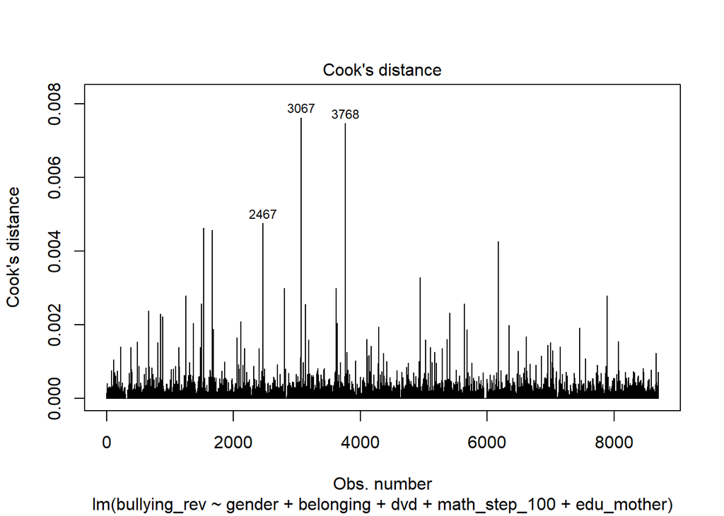

```r
plot(final_OLS, which = 4)
```

### Scale-Location (Heteroscedasticity)

The residuals are not randomly located. Also, ncvTest is significant (p < 0.05), that is a sign of heteroscedasticity.

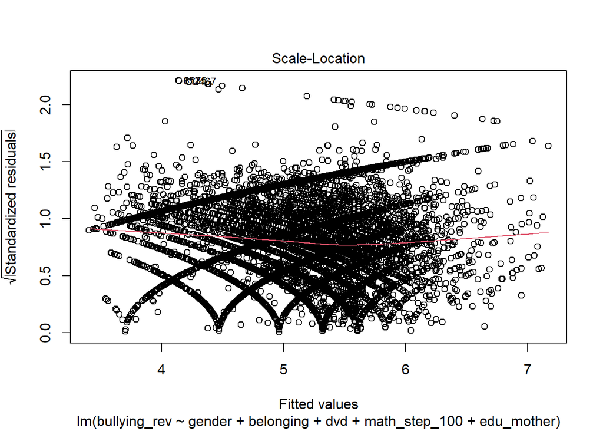

```r
plot(final_OLS, which = 3)
```

```r
car::ncvTest(final_OLS)
```

```
## Non-constant Variance Score Test
## Variance formula: ~ fitted.values
## Chisquare = 13.54165, Df = 1, p = 0.00023333
```

### Residuals Vs Fitted

Red line is close to be horizontal, which indicates a close-to-linear relationship

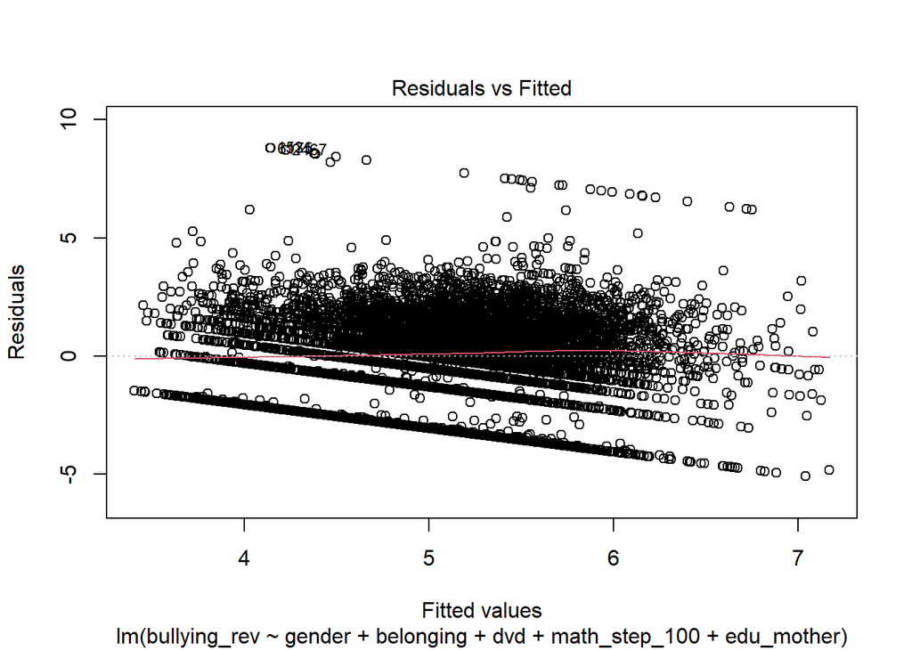

```r
plot(final_OLS, which = 1)
```

### Normal QQ

It’s not straight line, so the data isn’t normally distributed.

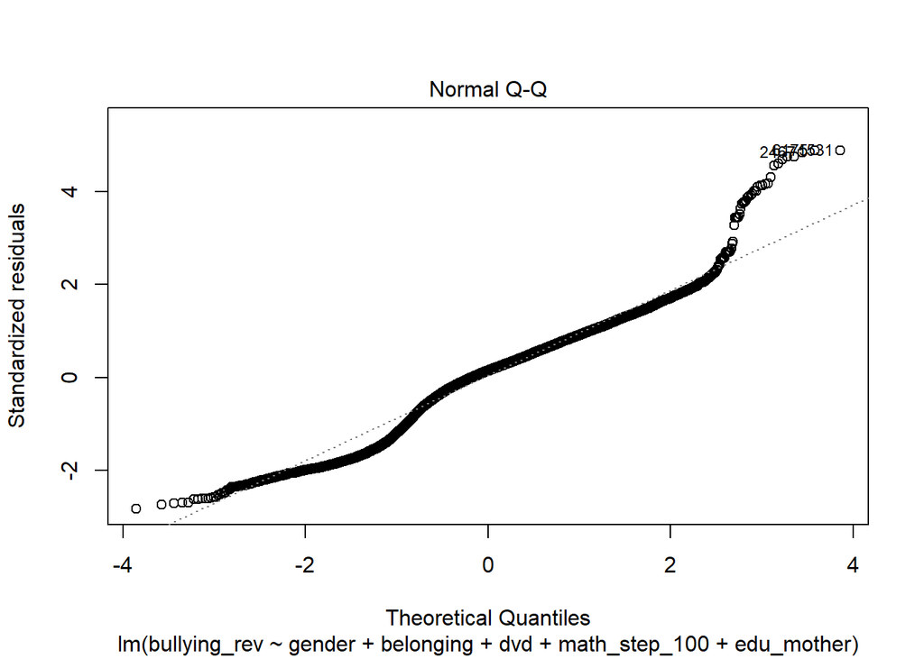

```r
plot(final_OLS, which = 2)
```

# 5. Now run a set of quantile regressions. Decide on the size of your quantile (20-10-5%?). Draw a plot summarizing the results. Interpret the results.

Since we are more interested in those respondents who were exposed to bullying and showed a high level of it, the last quantile should be small in order to capture them specifically. If we look at the number of respondents with a bullying level of 8 or higher, we will see that there are 368 of them, or 4,2% of our sample. But we can also see how the influence of our predictors on the level of bullying differs among those respondents who do not perceive it at all (with low level of bylling). There 1469 respondents with level of bulling 2 and lower, which is about 16%.

Therefore, I will take the quantile of 15%, 50% and 95%. As I understand it, we don’t need to select quantiles symmetrically, and if necessary, we can evaluate even one selected quantile, right?

So, the main differences between results of OLS regression and quantile regressions is associated with the variable “gender” and “math_test” (results of math test). As for other variables, confidential intervals of the OLS intersect with the confidential intervals of the quantiles. So there is no significant difference between them.

But about significant results, we can see following trends and differences:

1. **Gender** is not a statistically significant predictor for bullying for 95% quantile, but it remains significant for another quantiles and OLS.
2. **Math test**: is a statistically significant predictor for 95% quantile. There is a negative trend - an increase in the results of math test by 100 points entails a decrease of bulling level by 0.32 points. It is higher, then OLS has shown.

```r
nrow(data_USA %>% filter(bullying_rev >= 8))
```

```
## [1] 368
```

```r
nrow(data_USA %>% filter(bullying_rev <= 2))
```

```
## [1] 1469
```

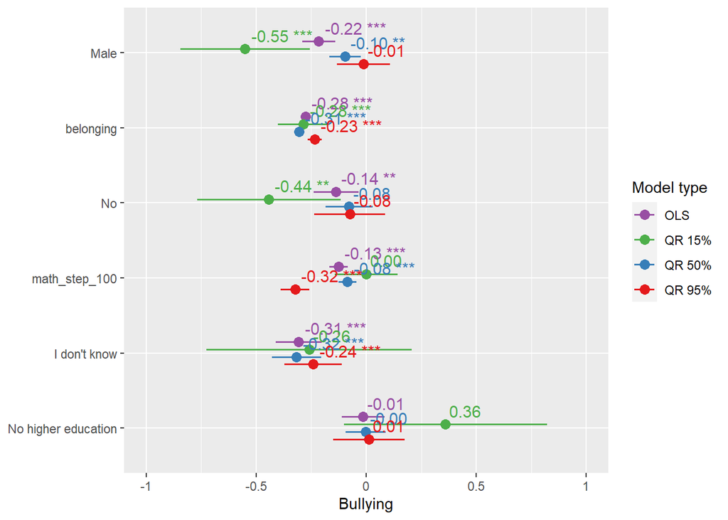

```r
quantile_15 <- rq(bullying_rev ~ gender + belonging + dvd + math_step_100 + edu_mother,
                data = data_USA, tau = 0.15)

quantile_50 <- rq(bullying_rev ~ gender + belonging + dvd + math_step_100 + edu_mother,
                data = data_USA, tau = 0.5)

quantile_95 <- rq(bullying_rev ~ gender + belonging + dvd + math_step_100 + edu_mother,
                data = data_USA, tau = 0.95)


plot_models(final_OLS, quantile_15, quantile_50, quantile_95,
            show.values = TRUE,
            m.labels = c("OLS", "QR 15%", "QR 50%", "QR 95%"),
            legend.title = "Model type")+
            ylab("Bullying")
```